# logic gates

PROBLEM STATEMENT: Implement simple logic network using MP neuron model

Logic gates are the basic building blocks of any digital system. It is an electronic circuit having one or more than one input and only one output. The relationship between the input and the output is based on a certain logic.

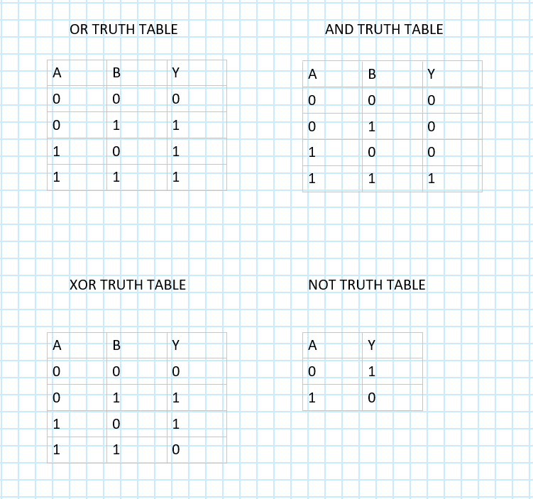

The early model of an artificial neuron is introduced by Warren McCulloch and Walter Pitts in 1943. The McCulloch-Pitts neural model is also known as linear threshold gate. It is a neuron of a set of inputs $ X_1, X_2, X_3, ..., X_m $ and one output $ y $. The linear threshold gate simply classifies the set of inputs into two different classes. Thus the output $ y $ is binary. Such a function can be described mathematically using these equations:

$\displaystyle Sum = \mathop{\sum_{i = 1}^{N}}{X_{i} W_{i}} + b, $

$\displaystyle y = f(Sum). $

$ W_1, W_2, W_3, ..., W_m$ are weight values normalized in the range of either $ (0,1)$ or $ (-1,1)$ and associated with each input line, $ Sum$ is the weighted sum, and $ T$ is a threshold constant

The function $ f$ is a linear step function at threshold $ T$

[figure not shown]

```python
# function for and gate
def and_gate(no1,no2):
    weight1 = 1
    weight2 = 1
    bias = -2
    ans1=gates(no1,no2,weight1,weight2,bias)
    return(ans1)
```

```python
# function for or gate
def or_gate(no1,no2):
    weight1 = 1
    weight2 = 1
    bias = -1
    ans2=gates(no1,no2,weight1,weight2,bias)
    return(ans2)
```

```python
# function for not gate
def not_gate(no1):
    no2 = 0
    weight1 = -1
    weight2 = 0
    bias = 0
    ans3 = gates(no1,no2,weight1,weight2,bias)
    return(ans3)
```

```python
# function for xor gate
def xor_gate(no1,no2):
        a=and_gate(no1,no2)
        c=or_gate(no1,no2)
        b=not_gate(a)
        d=and_gate(b,c)
        return(d)
```

```python
# function for implementing MP neuron model
def gates(no1,no2,weight1,weight2,bias):
    MP_neuron = weight1 * no1 + weight2 * no2 + bias
    output = int(MP_neuron >= 0)
    return(output)
```

```python
#enter the two inputs
n1=0
n2=1
```

```python
# printing the values according to the input given for each logic gate
print("\n AND operation gives:")
a=and_gate(n1,n2)
print(a)
print("\n OR operation gives:")
b=or_gate(n1,n2)
print(b)
print("\n NOT operation gives:")
c=not_gate(n1)
print(c)
print("\n XOR operation gives:")
xor_gate(n1,n2)
```

```
 AND operation gives:
0

 OR operation gives:
1

 NOT operation gives:
1

 XOR operation gives:
```

```
1
```

```python
# Enter the inputs for the function
A = 1
B = 0
C = 1
```

```python
#implementing a function
# (A and B) xor ((not(C) or A)

step1=and_gate(A,B)
step2=not_gate(C)
step3=or_gate(step2,A)
step4=xor_gate(step1,step3)
print(step4)
```

```
1
```